# Experimental treatment with edaravone in a mouse model of spinocerebellar ataxia 1

Hippocampal and cerebellar volume

Author

Martina Sucha, Simona Benediktova, Filip Tichanek, Jan Jedlicka, Stepan Kapl, Dana Jelinkova, Zdenka Purkartova, Jan Tuma, Jitka Kuncova, Jan Cendelin

This page shows R code for the study [Sucha et al.](https://www.mdpi.com/1422-0067/24/13/10689) (2023, *International Journal of Molecular Science*).

**Citation**:

> Sucha M, Benediktova S, Tichanek F, Jedlicka J, Kapl S, Jelinkova D, Purkartova Z, Tuma J, Kuncova J, Cendelin J. Experimental Treatment with Edaravone in a Mouse Model of Spinocerebellar Ataxia 1. International Journal of Molecular Sciences. 2023; 24(13):10689. https://doi.org/10.3390/ijms241310689

[GitHub page](https://github.com/filip-tichanek/edaravonSCA1): https://github.com/filip-tichanek/edaravonSCA1

This script analysis of hippocampal and cerebellar (molecular layer) volumes. For hippocampus, volume were analysed separately for both hippocampus with subject (mouse, *id*) as random-effect factor.

For hippocampus, volume was already estimated to be smaller in SCA mice ([Tichanek et al.](https://www.nature.com/articles/s41598-020-62308-0)) and this will be reflected in prior specification for the genotype effect

# 1 Upload of packages

```r
rm(list = ls())

suppressWarnings(suppressMessages( {
library(brms)
library(beeswarm)
library(vioplot)
library(glmmTMB)
library(car)
library(cowplot)
library(ggplot2)
library(tidyverse)
library(bayesplot)
library(gtsummary)
library(vegan)
library(knitr)
library(ggplot2)
  } ) )
```

# 2 Data upload and wrangling

```r
## Data upload
load("source_data/myEnvironment.RData")

## new and modified variable for hippocampal dataset
hp_vol$id <- as.factor(hp_vol$id)
hp_vol$group <- factor(hp_vol$group, levels=c('ctrl.wt','ctrl.sca','eda.sca'))

## new variable for cerebellar dataset
cbml$group<-relevel(cbml$group,ref='ctrl.sca')

## data summary
summary(hp_vol)
```

```
       id     treatment genotype sex    side       volume           group
 9      : 2   ctrl:16   sca:16   f:12   l:12   Min.   :1.184   ctrl.wt :8
 11     : 2   eda : 8   wt : 8   m:12   p:12   1st Qu.:1.688   ctrl.sca:8
 13     : 2                                    Median :1.899   eda.sca :8
 15     : 2                                    Mean   :1.827
 18     : 2                                    3rd Qu.:2.011
 19     : 2                                    Max.   :2.303
 (Other):12
    sex_num          group_sex
 Min.   :-0.5   ctrl.wt.f :4
 1st Qu.:-0.5   ctrl.wt.m :4
 Median : 0.0   ctrl.sca.f:4
 Mean   : 0.0   ctrl.sca.m:4
 3rd Qu.: 0.5   eda.sca.f :4
 Max.   : 0.5   eda.sca.m :4
```

```r
summary(cbml)
```

```
       id    treatment genotype sex       cb_ml            group
 9      :1   ctrl:8    sca:8    f:6   Min.   :16.56   ctrl.sca:4
 11     :1   eda :4    wt :4    m:6   1st Qu.:18.22   ctrl.wt :4
 13     :1                            Median :18.56   eda.sca :4
 15     :1                            Mean   :18.89
 18     :1                            3rd Qu.:19.47
 19     :1                            Max.   :21.64
 (Other):6
    sex_num          group_sex     volume
 Min.   :-0.5   ctrl.wt.f :2   Min.   :16.56
 1st Qu.:-0.5   ctrl.wt.m :2   1st Qu.:18.22
 Median : 0.0   ctrl.sca.f:2   Median :18.56
 Mean   : 0.0   ctrl.sca.m:2   Mean   :18.89
 3rd Qu.: 0.5   eda.sca.f :2   3rd Qu.:19.47
 Max.   : 0.5   eda.sca.m :2   Max.   :21.64
```

# 3 Hippocampal volume

## 3.1 Data exploration

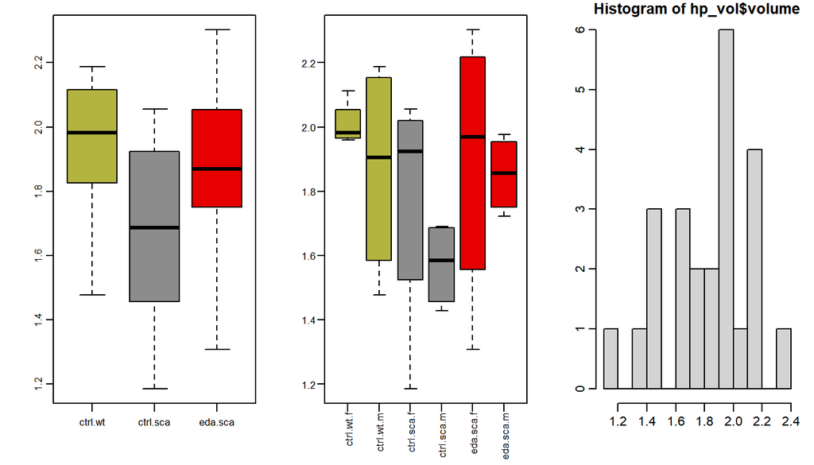

```r
## setting spacing
par(mfrow=c(1,3))
par(mar=c(4,3.5,1,1))
par(mgp=c(4,0.6,0))

## both sex together
plot(hp_vol$volume~hp_vol$group,
     col=cola, cex.axis=0.8)


## by both group and sex
plot(hp_vol$volume~hp_vol$group_sex,
     col=cola[c(1,1,2,2,3,3,4,4)],cex.axis=0.8, las=2)


## data distribution
hist(hp_vol$volume, 12)
```

Some values seem to be weirdly smaller and distribution seems to include outliers on low values, or heavy left-tail. This suggest that volume may be better modelled with robust regression.

## 3.2 Modelling

### 3.2.1 Prirs specifications

Summary statistics to get priors

```r
hp_vol$group<-relevel(hp_vol$group,ref='ctrl.sca')


hp_scirep <- glmmTMB(DG_ML_volume~genotype,data=young_scirep)
summary(hp_scirep)
```

```
 Family: gaussian  ( identity )
Formula:          DG_ML_volume ~ genotype
Data: young_scirep

     AIC      BIC   logLik deviance df.resid
     2.9      7.6      1.6     -3.1       33


Dispersion estimate for gaussian family (sigma^2): 0.0537

Conditional model:
            Estimate Std. Error z value Pr(>|z|)
(Intercept)  2.66767    0.05182   51.48  < 2e-16 ***
genotypew    0.52591    0.07773    6.77 1.32e-11 ***
---
Signif. codes:  0 '***' 0.001 '**' 0.01 '*' 0.05 '.' 0.1 ' ' 1
```

```r
sd(young_scirep$DG_ML_volume, na.rm=TRUE)
```

```
[1] 0.354233
```

```r
sd(hp_vol$volume)*c(5, 2, 1.2, 1)
```

```
[1] 1.4549249 0.5819699 0.3491820 0.2909850
```

```r
mean(hp_vol$volume)
```

```
[1] 1.827024
```

```r
prios(hp_scirep)
```

```
 Estimate
0.3735612 0.5603419
```

In previous publication, the volume was measured in molecular layer of dentate gyrus, so the methodology was slightly different and SD differ. The estimated prior will be thus adjusted for different variability

```r
0.37 *(0.29/0.354)
```

```
[1] 0.3031073
```

```r
0.56 *(0.29/0.354)
```

```
[1] 0.4587571
```

Setting priors

```r
prior01 <- c(set_prior("student_t(3, 1.83, 1.45)", class = "b", coef = "Intercept"),
             set_prior("normal(0.3, 0.46)", class = "b", coef = "groupctrl.wt"),
             set_prior("normal(0, 0.34)"  , class = "b", coef = "groupeda.sca"))
```

### 3.2.2 Model fitting

Robust will be preffered, but compare it also with simpler Gaussian

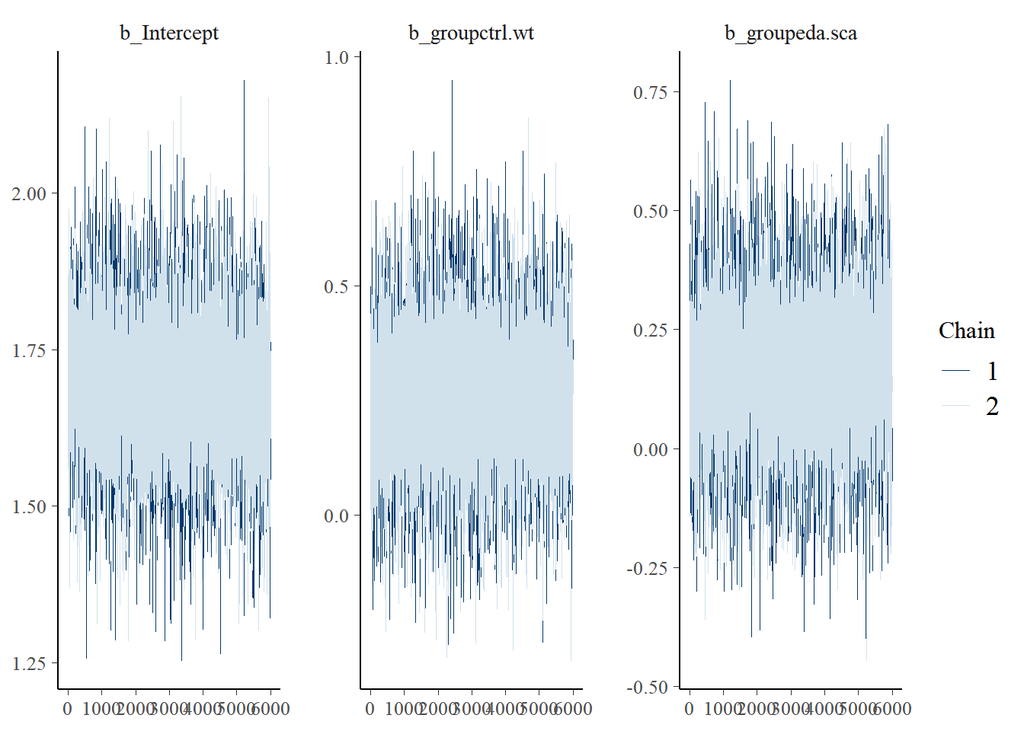

```r
m_hp_vol <- run_model(
        brm(volume~0+Intercept+group+ (1|id),
                data=hp_vol, prior = prior01,
                family=student(),
                save_pars = save_pars(all = TRUE),
                iter=8000, warmup=2000,chains=2,cores=2,seed=17,
                control = list(adapt_delta = 0.99)),
               'output/brm/m_hp_vol', reuse = TRUE)

m_hp_vol_g <- run_model(
        brm(volume~0+Intercept+group+ (1|id),
                data=hp_vol, prior = prior01,
                family= gaussian(),
                save_pars = save_pars(all = TRUE),
                iter=8000, warmup=2000,chains=2,cores=2,seed=17,
                control = list(adapt_delta = 0.99)),
               'output/brm/m_hp_vol_g', reuse = TRUE)

## chains for crucial fixed-effect predictors
mcmc_trace(m_hp_vol, pars = c('b_Intercept',
                               'b_groupctrl.wt',
                               'b_groupeda.sca'))
```

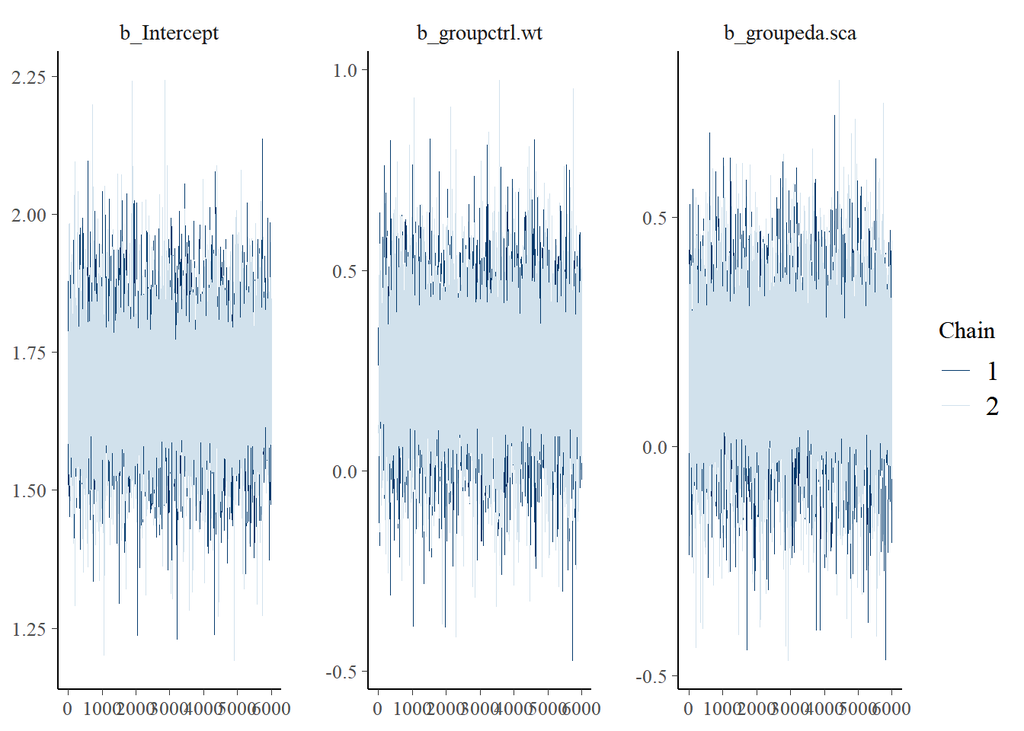

```r
mcmc_trace(m_hp_vol_g, pars = c('b_Intercept',
                               'b_groupctrl.wt',
                               'b_groupeda.sca'))
```

```r
## summary of models

summary(m_hp_vol)
```

```
 Family: student
  Links: mu = identity; sigma = identity; nu = identity
Formula: volume ~ 0 + Intercept + group + (1 | id)
   Data: hp_vol (Number of observations: 24)
  Draws: 2 chains, each with iter = 8000; warmup = 2000; thin = 1;
         total post-warmup draws = 12000

Group-Level Effects:
~id (Number of levels: 12)
              Estimate Est.Error l-95% CI u-95% CI Rhat Bulk_ESS Tail_ESS
sd(Intercept)     0.09      0.07     0.00     0.26 1.00     6548     6181

Population-Level Effects:
             Estimate Est.Error l-95% CI u-95% CI Rhat Bulk_ESS Tail_ESS
Intercept        1.69      0.11     1.47     1.91 1.00     8355     8230
groupctrl.wt     0.26      0.15    -0.04     0.56 1.00     9048     7727
groupeda.sca     0.16      0.15    -0.14     0.46 1.00     9868     8821

Family Specific Parameters:
      Estimate Est.Error l-95% CI u-95% CI Rhat Bulk_ESS Tail_ESS
sigma     0.28      0.05     0.19     0.40 1.00    13725     8363
nu       21.80     14.22     4.03    57.72 1.00    14526     6822

Draws were sampled using sampling(NUTS). For each parameter, Bulk_ESS
and Tail_ESS are effective sample size measures, and Rhat is the potential
scale reduction factor on split chains (at convergence, Rhat = 1).
```

```r
summary(m_hp_vol_g)
```

```
 Family: gaussian
  Links: mu = identity; sigma = identity
Formula: volume ~ 0 + Intercept + group + (1 | id)
   Data: hp_vol (Number of observations: 24)
  Draws: 2 chains, each with iter = 8000; warmup = 2000; thin = 1;
         total post-warmup draws = 12000

Group-Level Effects:
~id (Number of levels: 12)
              Estimate Est.Error l-95% CI u-95% CI Rhat Bulk_ESS Tail_ESS
sd(Intercept)     0.09      0.07     0.00     0.26 1.00     5322     4899

Population-Level Effects:
             Estimate Est.Error l-95% CI u-95% CI Rhat Bulk_ESS Tail_ESS
Intercept        1.69      0.11     1.48     1.92 1.00     7954     7076
groupctrl.wt     0.25      0.16    -0.05     0.56 1.00     8493     8242
groupeda.sca     0.16      0.15    -0.14     0.45 1.00     8773     7281

Family Specific Parameters:
      Estimate Est.Error l-95% CI u-95% CI Rhat Bulk_ESS Tail_ESS
sigma     0.30      0.05     0.22     0.42 1.00    11829     7875

Draws were sampled using sampling(NUTS). For each parameter, Bulk_ESS
and Tail_ESS are effective sample size measures, and Rhat is the potential
scale reduction factor on split chains (at convergence, Rhat = 1).
```

Both shows good convergence, sufficient ESS and practically the same results

### 3.2.3 PPC

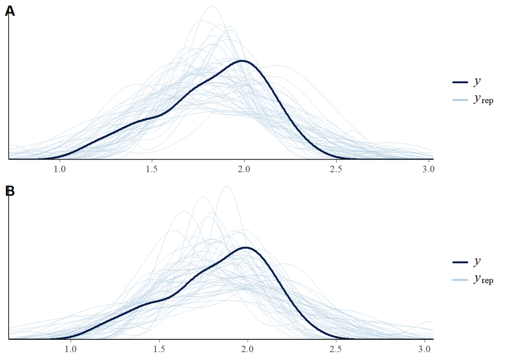

```r
pla<-pp_check(m_hp_vol,type='dens_overlay',ndraws = 50)
plb<-pp_check(m_hp_vol_g,type='dens_overlay',ndraws = 50)
plot_grid(pla, plb, labels=c("A", "B"), ncol = 1, nrow = 2)
```

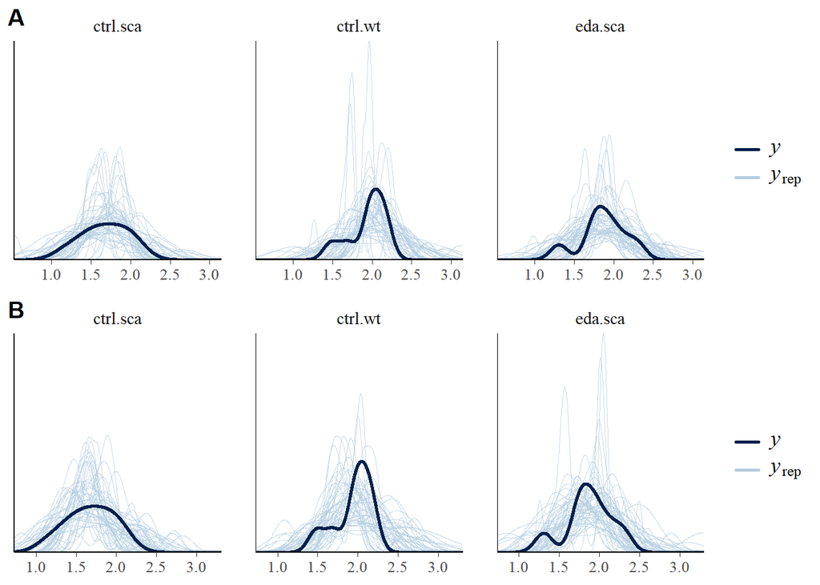

```r
pla<-pp_check(m_hp_vol,type='dens_overlay_grouped',ndraws = 50,group='group')
plb<-pp_check(m_hp_vol_g,type='dens_overlay_grouped',ndraws = 50,group='group')
plot_grid(pla, plb, labels=c("A", "B"), ncol = 1, nrow = 2)
```

```r
pla<-pp_check(m_hp_vol,type='scatter_avg')
```

```
Using all posterior draws for ppc type 'scatter_avg' by default.
```

```r
plb<-pp_check(m_hp_vol_g,type='scatter_avg')
```

```
Using all posterior draws for ppc type 'scatter_avg' by default.
```

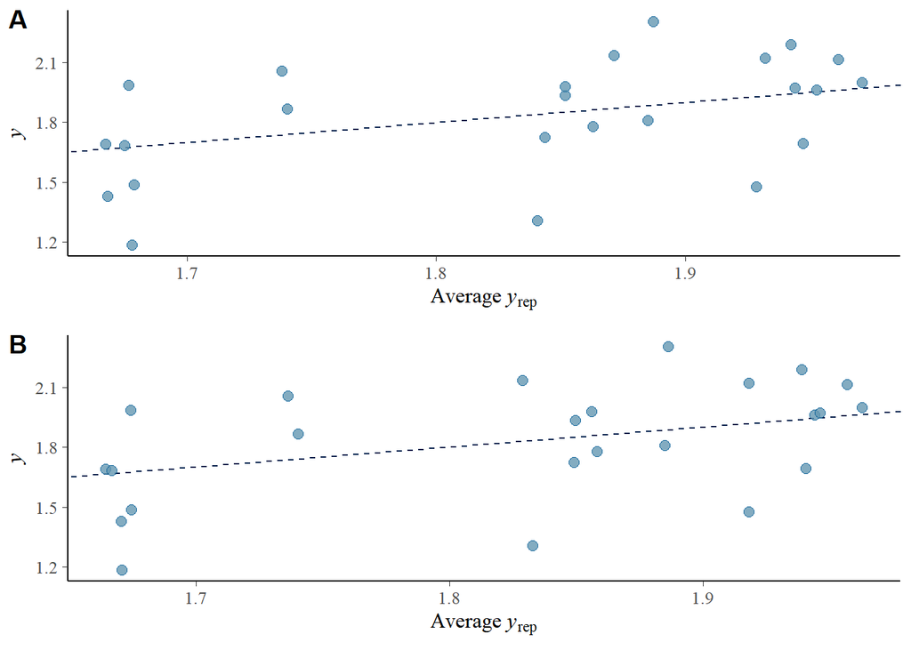

```r
plot_grid(pla, plb, labels=c("A", "B"), ncol = 1, nrow = 2)
```

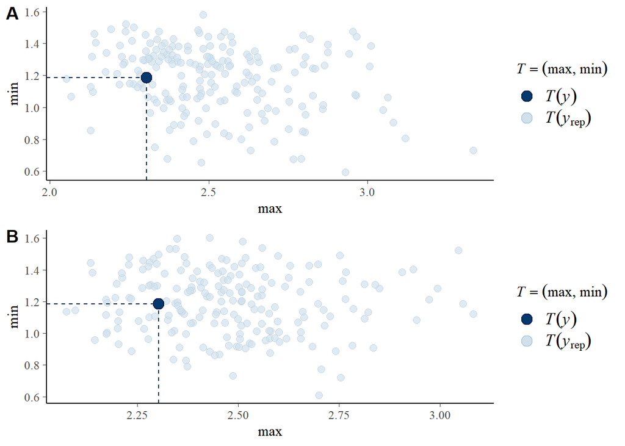

```r
pla<-pp_check(m_hp_vol,type="stat_2d", stat = c("max", "min"),ndraws=200)
plb<-pp_check(m_hp_vol_g,type="stat_2d", stat = c("max", "min"),ndraws=200)
plot_grid(pla, plb, labels=c("A", "B"), ncol = 1, nrow = 2)
```

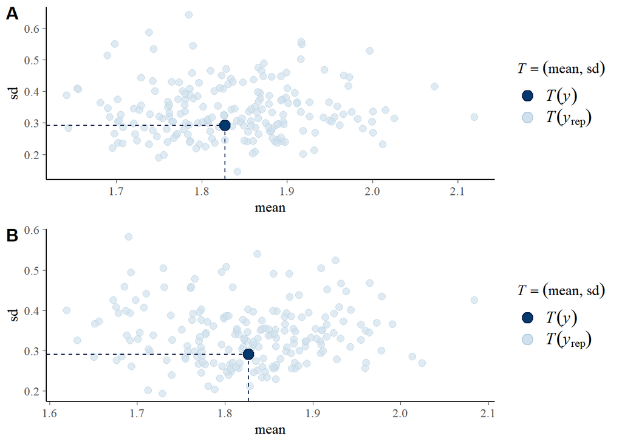

```r
pla<-pp_check(m_hp_vol,type="stat_2d", stat = c("mean", "sd"),ndraws=200)
plb<-pp_check(m_hp_vol_g,type="stat_2d", stat = c("mean", "sd"),ndraws=200)
plot_grid(pla, plb, labels=c("A", "B"), ncol = 1, nrow = 2)
```

```r
### Are there too influential observations?
par(mfrow=c(1,2))
plot(loo(m_hp_vol));loo(m_hp_vol)
```

```
Computed from 12000 by 24 log-likelihood matrix

         Estimate  SE
elpd_loo     -7.3 3.2
p_loo         5.1 1.0
looic        14.6 6.3
------
Monte Carlo SE of elpd_loo is 0.0.

Pareto k diagnostic values:
                         Count Pct.    Min. n_eff
(-Inf, 0.5]   (good)     20    83.3%   3609
 (0.5, 0.7]   (ok)        4    16.7%   1882
   (0.7, 1]   (bad)       0     0.0%   <NA>
   (1, Inf)   (very bad)  0     0.0%   <NA>

All Pareto k estimates are ok (k < 0.7).
See help('pareto-k-diagnostic') for details.
```

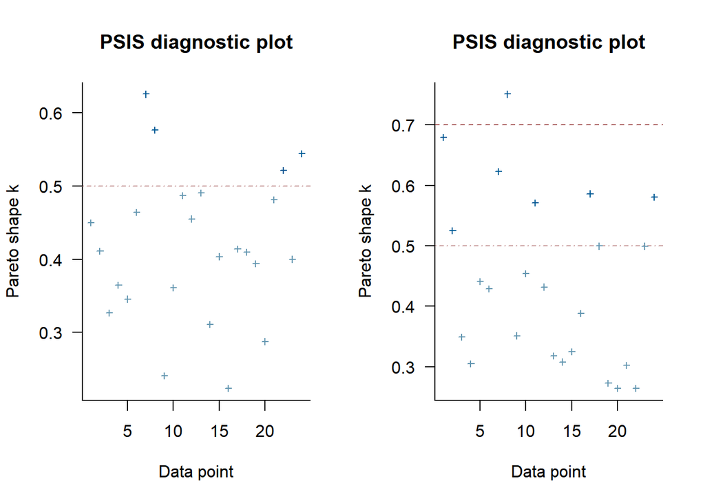

```
Computed from 12000 by 24 log-likelihood matrix

         Estimate  SE
elpd_loo     -7.2 3.1
p_loo         4.9 1.1
looic        14.3 6.2
------
Monte Carlo SE of elpd_loo is NA.

Pareto k diagnostic values:
                         Count Pct.    Min. n_eff
(-Inf, 0.5]   (good)     17    70.8%   1473
 (0.5, 0.7]   (ok)        6    25.0%   1648
   (0.7, 1]   (bad)       1     4.2%   1964
   (1, Inf)   (very bad)  0     0.0%   <NA>
See help('pareto-k-diagnostic') for details.
```

```r
plot(loo(m_hp_vol_g));loo(m_hp_vol_g)
```

Both show good PPC. However, as expected, Gaussian model show overly influential observations (low-values outliers). Robust regression is thus natural choice.

### 3.2.4 Posterior draws extraction

```r
post_fix_hp_vol <- as.data.frame(m_hp_vol, variable = c("b_Intercept","b_groupctrl.wt",
                                                      "b_groupeda.sca"), )
names(post_fix_hp_vol)[1]<-"sca_ctrl"

post_fix_hp_vol$wt_ctrl<-post_fix_hp_vol$sca_ctrl+post_fix_hp_vol$b_groupctrl.wt
post_fix_hp_vol$sca_eda<-post_fix_hp_vol$sca_ctrl+post_fix_hp_vol$b_groupeda.sca
summary(post_fix_hp_vol)
```

```
    sca_ctrl     b_groupctrl.wt    b_groupeda.sca        wt_ctrl
 Min.   :1.253   Min.   :-0.3184   Min.   :-0.44631   Min.   :1.409
 1st Qu.:1.621   1st Qu.: 0.1555   1st Qu.: 0.06417   1st Qu.:1.876
 Median :1.692   Median : 0.2562   Median : 0.16171   Median :1.951
 Mean   :1.693   Mean   : 0.2568   Mean   : 0.16213   Mean   :1.950
 3rd Qu.:1.765   3rd Qu.: 0.3559   3rd Qu.: 0.26127   3rd Qu.:2.024
 Max.   :2.181   Max.   : 0.9485   Max.   : 0.77453   Max.   :2.523
    sca_eda
 Min.   :1.193
 1st Qu.:1.783
 Median :1.856
 Mean   :1.855
 3rd Qu.:1.928
 Max.   :2.511
```

```r
groupquant_hp_vol<-sapply(post_fix_hp_vol[,c(4,1,5)],
                          function(p) quantile(p, probs = c(0.025,0.975,0.5)))
```

## 3.3 Data and model visualization

In data visualization, individual points represent average per subject. Violin plot (area indicating data distribution) was, in contrast, constructed on the basis of individual data points (non-averaged, 1 animals thus generated two data-points)

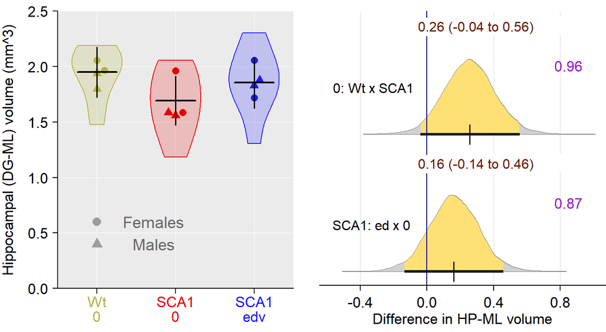

```r
suppressWarnings(suppressMessages( {
range<-c(0,2.5);scal<-range[2]-range[1]

par(mfrow=c(1,2))
par(mar=c(2,3,0,0))
par(mgp=c(2,0.6,0))


hp_vol$group<-factor(hp_vol$group,levels=c('ctrl.wt','ctrl.sca','eda.sca'))


xrange<-c(0.5,3.5);xscal=xrange[2]-xrange[1]
plot(NULL,xlim=c(xrange[1],xrange[2]),ylim=c(range[1],range[2]),xlab="",
     ylab="Hippocampal (DG-ML) volume (mm^3)",las=1, axes=FALSE,cex.lab=1.1)

rect(xrange[1],range[2],xrange[2],range[1],col="grey92",border=NA)
x<-range[1]
repeat{
  lines(c(xrange[1],xrange[2]),c(x,x),col="white",lwd=0.7)
  x=x+0.5;if(x>range[2]){break}}

x<-0
repeat{
  lines(c(x,x),c(range[1],range[2]),col="white",lwd=0.7)
  x=x+1;if(x>3.5){break}}

vioplot(hp_vol$vol~hp_vol$group,col=colb[-2],at=c(1:4),add=T,
        border=cola[-2],axes=FALSE,drawRect=F,lwd=1,wex=0.8)

hp_vol_sum <- hp_vol %>% group_by(id, group, sex_num) %>% summarize(hpvoll = mean(volume))


beeswarm(hp_vol_sum$hpvoll~hp_vol_sum$group,col=cola[-2],at=c(1:3),
         add=T,pwpch=(16.5+hp_vol_sum$sex_num), cex=1.2 )

tp<-(groupquant_hp_vol[3,])
xx<-1;wid=0.25
repeat{
  lines(c(xx-wid,xx+wid),c(tp[xx],tp[xx]),lwd=2,col="black");
  lines(c(xx,xx),c(groupquant_hp_vol[1,xx],groupquant_hp_vol[2,xx]),lwd=1.7,col="black")
  xx<-xx+1
  if(xx>3){break}}

tckk=-0.02
axis(2,las=2,cex.axis=1.1,at=seq(range[1],range[2],by=0.5),
     labels=c(rep("",length(seq(range[1],range[2],by=0.5)))),pos=xrange[1],tck=tckk)
axis(2,las=2,cex.axis=1.1,at=seq(range[1],range[2],by=0.5),pos=xrange[1],tck=tckk)

axis(side=1,las=1,cex.axis=1.1,at=c(seq(1,3,by=1)),
     labels=c(rep("",length(seq(1,3,by=1)))),pos=range[1],tck=tckk)
lines(c(xrange[1],xrange[2]),c(range[1],range[1]))
text(c(1:3),c(rep(range[1]-0.046*scal,3)),xpd=T,cex=1.1,col=cola[-2],
     c("Wt", "SCA1", "SCA1"))
ypo<-c(range[1]-0.1*scal,range[1]-0.1*scal)
text(c(1:4),c(ypo[1],ypo[2],ypo[1],ypo[2]),xpd=T,cex=1.1,col=cola[-2],
     c("0", "0", "edv"))

ypos<-0.6;xpos=1
points(xpos,ypos,pch=16,cex=1.4,col=rgb(0.4,0.4,0.4,alpha=0.6))
text(xpos+0.24*xscal,ypos,"Females",col="grey40",cex=1.2)
points(xpos,ypos-0.08*scal,pch=17,cex=1.4,col=rgb(0.4,0.4,0.4,alpha=0.6))
text(xpos+0.24*xscal,ypos-0.08*scal,"Males",col="grey40",cex=1.2)

### probability distributions --------
par(mar=c(2.2,1,0,0))
dif<-data.frame(post_fix_hp_vol$b_groupeda.sca,
                post_fix_hp_vol$b_groupctrl.wt)
dif<-(dif)

yla<-"Difference in HP-ML volume"
tckk=-0.018
ste<-seq(-0.8, 1.2,by=0.4)
mons_poste(dif,0)

zpos=seq(-0.05,1,1/2)
xx=1;ind=0.6;xpol<- -0.32

text(xpol,zpos[xx]+zpos[2]*ind,
     "SCA1: ed x 0 ",cex=1, srt = 0)
xx=xx+1

text(xpol,zpos[xx]+zpos[2]*ind,
     "0: Wt x SCA1",cex=1, srt = 0)


} ) )
```

# 4 Cerebellar volumes

The analysis will be done in the same way as for hippocampus

# 5 Data exploration

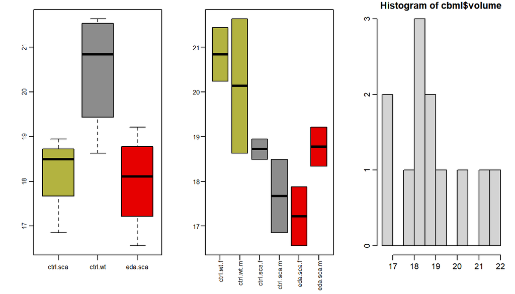

```r
## setting spacing
par(mfrow=c(1,3))
par(mar=c(4,3.5,1,1))
par(mgp=c(4,0.6,0))

## both sex together
plot(cbml$volume~cbml$group,
     col=cola, cex.axis=0.8)


## by both group and sex
plot(cbml$volume~cbml$group_sex,
     col=cola[c(1,1,2,2,3,3,4,4)],cex.axis=0.8, las=2)


## data distribution
hist(cbml$volume, 12)
```

## 5.1 Modelling

### 5.1.1 Setting priors

Summary statistics for prior specification

```r
  sd(cbml$volume)*c(5, 2, 1.2, 1)
```

```
[1] 7.871047 3.148419 1.889051 1.574209
```

```r
  mean(cbml$volume)
```

```
[1] 18.89216
```

Prior specification

```r
 cbml$group<-relevel(cbml$group,ref='ctrl.sca')

  prior01 <- c(set_prior("student_t(3, 19, 8)", class = "b", coef = "Intercept"),
               set_prior("normal(0, 3.15)", class = "b", coef = "groupctrl.wt"),
               set_prior("normal(0, 1.9)"  , class = "b", coef = "groupeda.sca"))
```

### 5.1.2 Fitting the model

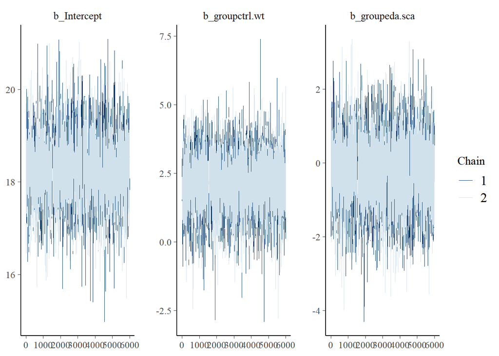

```r
  m_cbml <- run_model(brm(volume~0+Intercept+group,
                data=cbml, prior = prior01,
                family=student(),
                save_pars = save_pars(all = TRUE),
                iter=8000, warmup=2000,chains=2,cores=2,seed=17,
                control = list(adapt_delta = 0.999)),
             'output/brm/m_cbml', reuse = TRUE)

## chains mixing and convergence
mcmc_trace(m_cbml, pars = c('b_Intercept',
                               'b_groupctrl.wt',
                               'b_groupeda.sca'))
```

```r
## model summary
summary(m_cbml)
```

[output not shown]

Convergence and ESS are fine

### 5.1.3 PPC

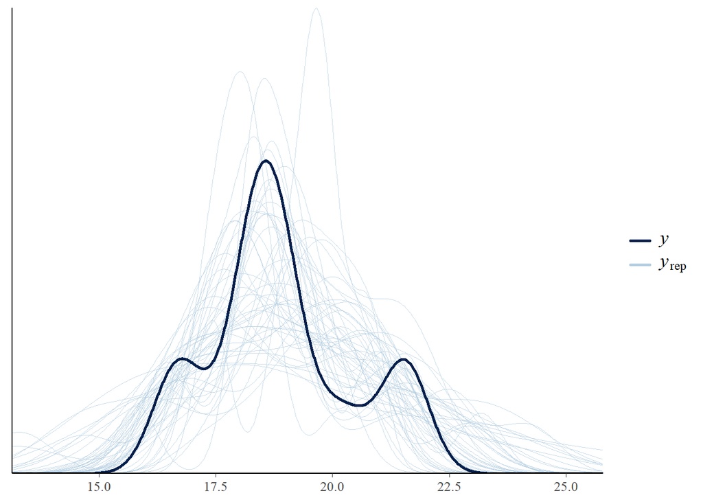

```r
pp_check(m_cbml,type='dens_overlay',ndraws = 50)
```

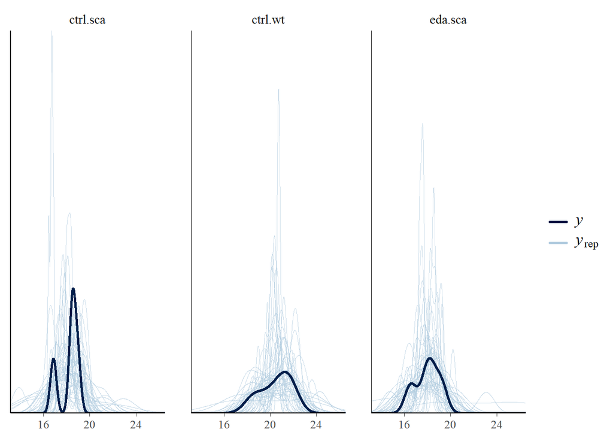

```r
pp_check(m_cbml,type='dens_overlay_grouped',ndraws = 50,group='group')
```

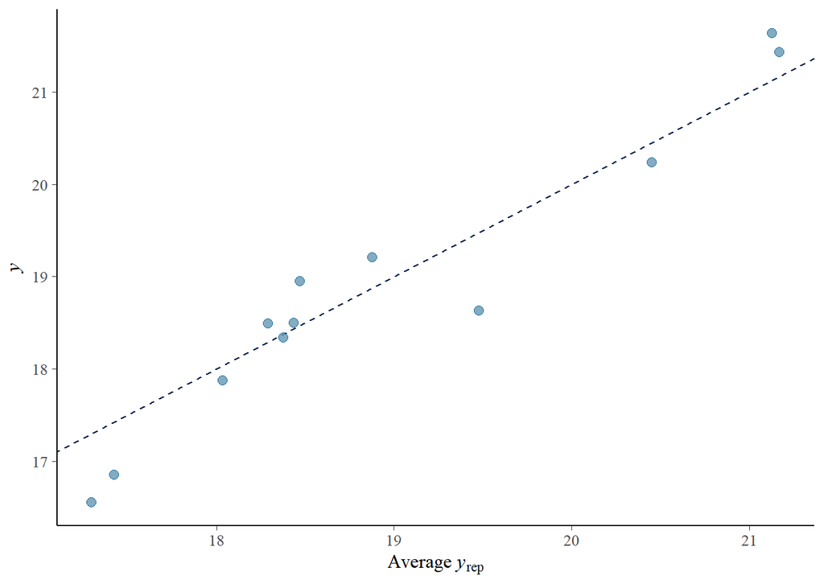

```r
pp_check(m_cbml,type='scatter_avg', ndraws = 50)
```

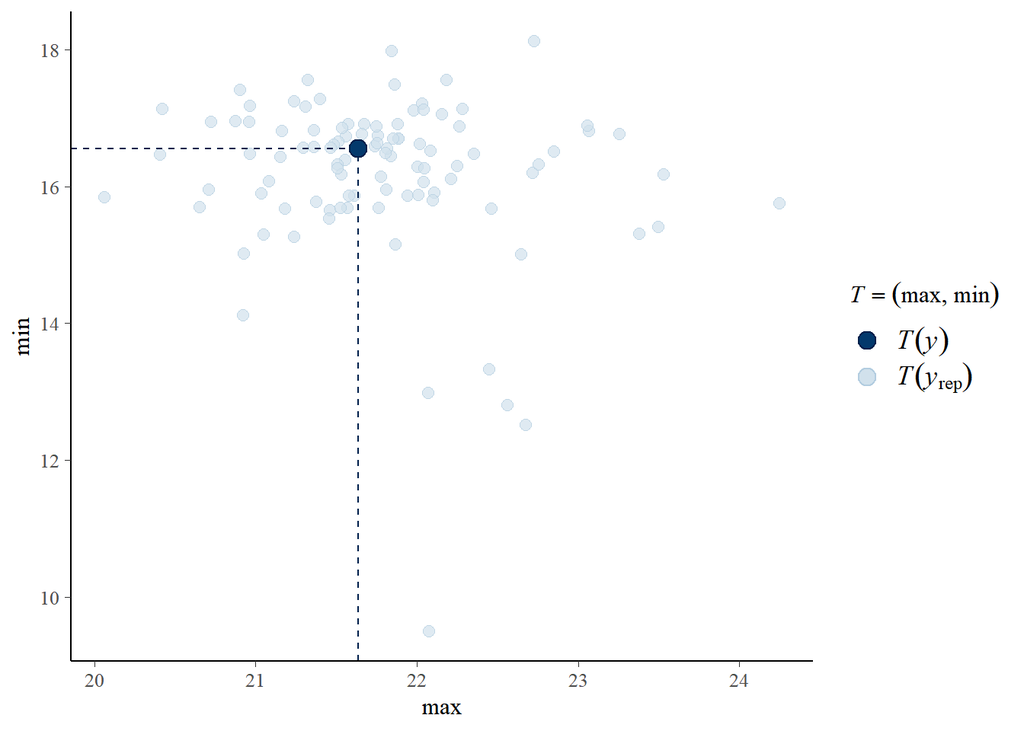

```r
pp_check(m_cbml,type="stat_2d", stat = c("max", "min"),ndraws=100)
```

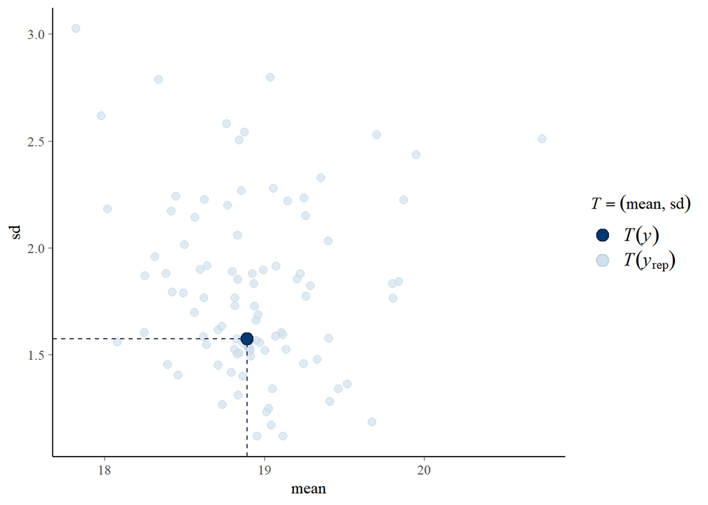

```r
pp_check(m_cbml,type="stat_2d", stat = c("mean", "sd"),ndraws=100)
```

### 5.1.4 Extraction of posterior samples

```r
post_fix_cbml <- as.data.frame(m_cbml, variable = c("b_Intercept","b_groupctrl.wt",
                                                        "b_groupeda.sca"), )
names(post_fix_cbml)[1]<-"sca_ctrl"

post_fix_cbml$wt_ctrl<-post_fix_cbml$sca_ctrl+post_fix_cbml$b_groupctrl.wt
post_fix_cbml$sca_eda<-post_fix_cbml$sca_ctrl+post_fix_cbml$b_groupeda.sca
summary(post_fix_cbml)
```

```
    sca_ctrl     b_groupctrl.wt   b_groupeda.sca       wt_ctrl
 Min.   :14.98   Min.   :-2.906   Min.   :-4.3060   Min.   :16.49
 1st Qu.:17.86   1st Qu.: 1.537   1st Qu.:-0.7981   1st Qu.:19.97
 Median :18.27   Median : 2.134   Median :-0.2444   Median :20.42
 Mean   :18.28   Mean   : 2.118   Mean   :-0.2324   Mean   :20.40
 3rd Qu.:18.69   3rd Qu.: 2.726   3rd Qu.: 0.3276   3rd Qu.:20.85
 Max.   :21.09   Max.   : 7.393   Max.   : 3.3551   Max.   :23.57
    sca_eda
 Min.   :14.65
 1st Qu.:17.63
 Median :18.04
 Mean   :18.05
 3rd Qu.:18.46
 Max.   :21.31
```

```r
groupquant_cbml<-sapply(post_fix_cbml[,c(4,1,5)],
                        function(p) quantile(p, probs = c(0.025,0.975,0.5)))
```

## 5.2 Data and model visualization

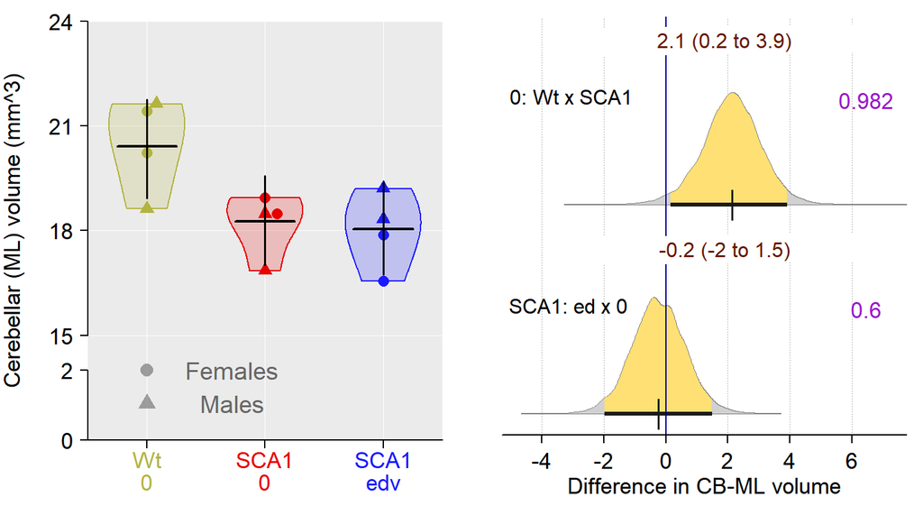

```r
suppressWarnings(suppressMessages( {
range<-c(12,24);scal<-range[2]-range[1]

par(mfrow=c(1,2))
par(mar=c(2,3,0.2,0.2))
par(mgp=c(2,0.6,0))


cbml$group<-factor(cbml$group,levels=c('ctrl.wt','ctrl.sca','eda.sca'))


xrange<-c(0.5,3.5);xscal=xrange[2]-xrange[1]
plot(NULL,xlim=c(xrange[1],xrange[2]),ylim=c(range[1],range[2]),xlab="",
     ylab="Cerebellar (ML) volume (mm^3)",las=1, axes=FALSE,cex.lab=1.1)

rect(xrange[1],range[2],xrange[2],range[1],col="grey92",border=NA)
x<-range[1]
repeat{
  lines(c(xrange[1],xrange[2]),c(x,x),col="white",lwd=0.7)
  x=x+3;if(x>range[2]){break}}

x<-0
repeat{
  lines(c(x,x),c(range[1],range[2]),col="white",lwd=0.7)
  x=x+1;if(x>3.5){break}}

vioplot(cbml$vol~cbml$group,col=colb[-2],at=c(1:4),add=T,
        border=cola[-2],axes=FALSE,drawRect=F,lwd=1,wex=0.8)

cbml_sum <- cbml %>% group_by(id, group, sex_num) %>% summarize(cbvoll = mean(volume))


beeswarm(cbml_sum$cbvoll~cbml_sum$group,col=cola[-2],at=c(1:3),
         add=T,pwpch=(16.5+cbml_sum$sex_num), cex=1.2 )

tp<-(groupquant_cbml[3,])
xx<-1;wid=0.25
repeat{
  lines(c(xx-wid,xx+wid),c(tp[xx],tp[xx]),lwd=2,col="black");
  lines(c(xx,xx),c(groupquant_cbml[1,xx],groupquant_cbml[2,xx]),lwd=1.7,col="black")
  xx<-xx+1
  if(xx>3){break}}

tckk=-0.02

axis(2,las=2,cex.axis=1.1,at=c(seq(range[1],14,by=3),14),
     labels=c('0','2'),pos=xrange[1],tck=tckk)

axis(2,las=2,cex.axis=1.1,at=c(seq(15,range[2],by=3)),,pos=xrange[1],tck=tckk)

axis(side=1,las=1,cex.axis=1.1,at=c(seq(1,3,by=1)),
     labels=c(rep("",length(seq(1,3,by=1)))),pos=range[1],tck=tckk)
lines(c(xrange[1],xrange[2]),c(range[1],range[1]))
text(c(1:3),c(rep(range[1]-0.046*scal,3)),xpd=T,cex=1.1,col=cola[-2],
     c("Wt", "SCA1", "SCA1"))
ypo<-c(range[1]-0.1*scal,range[1]-0.1*scal)
text(c(1:4),c(ypo[1],ypo[2],ypo[1],ypo[2]),xpd=T,cex=1.1,col=cola[-2],
     c("0", "0", "edv"))

ypos<-14;xpos=1
points(xpos,ypos,pch=16,cex=1.4,col=rgb(0.4,0.4,0.4,alpha=0.6))
text(xpos+0.24*xscal,ypos,"Females",col="grey40",cex=1.2)
points(xpos,ypos-0.08*scal,pch=17,cex=1.4,col=rgb(0.4,0.4,0.4,alpha=0.6))
text(xpos+0.24*xscal,ypos-0.08*scal,"Males",col="grey40",cex=1.2)

### probability distributions --------
ypos<-0.6;xpos=1
range=c(0, 24)
scal = 12
par(mar=c(2.2,1,0,0))
dif<-data.frame(post_fix_cbml$b_groupeda.sca,
                post_fix_cbml$b_groupctrl.wt)
dif<-(dif)

yla<- "Difference in CB-ML volume"
tckk= -0.018
ste<- seq(-4, 6, by=2)
mons_poste(dif,0)

zpos=seq(-0.05,1,1/2)
xx=1;ind=0.8;xpol<- -3.05

text(xpol,zpos[xx]+zpos[2]*ind,
     "SCA1: ed x 0 ",cex=1, srt = 0)
xx=xx+1

text(xpol,zpos[xx]+zpos[2]*ind,
     "0: Wt x SCA1",cex=1, srt = 0)


} ) )
```